# Mann-Whitney is (almost) an independent-sample t-test on ranks

Jonas Kristoffer Lindeløv

August 31, 2018

This document presents the close relationship between the p-values of the Mann-Whitney U test and a two-sample t-test on the ranked data. It is an appendix to the post “[Common statistical tests as linear models](https://rpubs.com/lindeloev/test_as_linear)”.

TL;DR: I argue below that starting at N = 12, 5the t-test is a reasonable approximation. For N > 30, it is almost exact.

Since the Mann-Whitney U is a Wilcoxon test, it may also be worth looking at my equivalent simulation about whether Wilcoxon Signed Rank test is identical to a ranked one-sample t-test.

# Small example

First, let’s find a way tocreate some clearly non-normal data. How about this ex-gaussian + uniform values in the negative end:

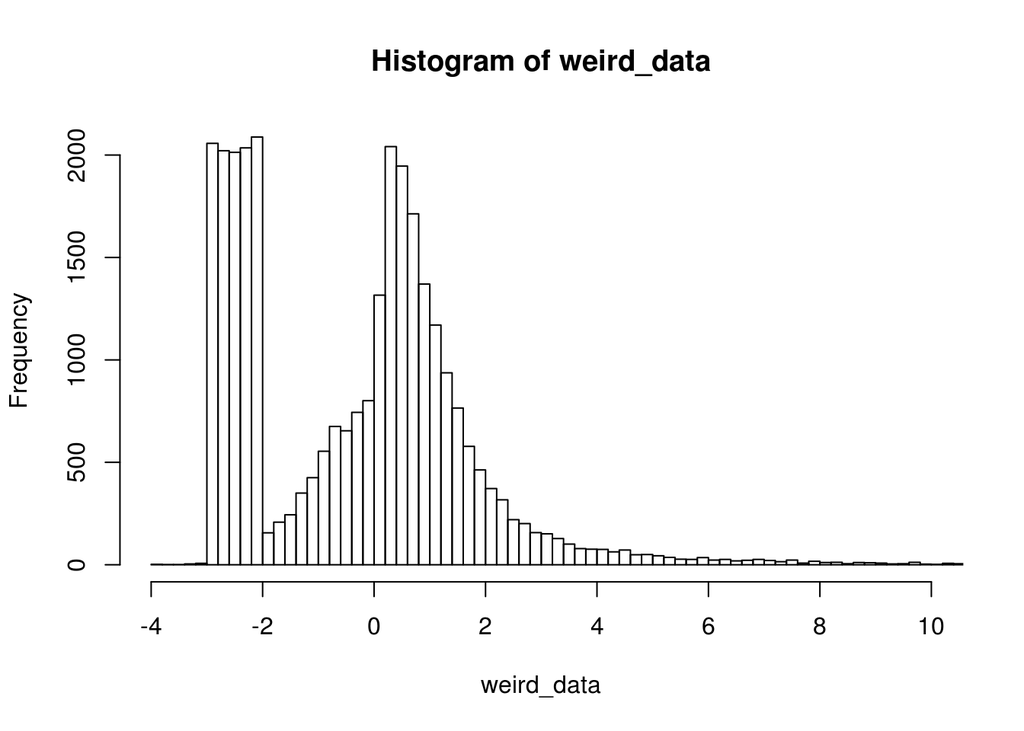

```r
weird_data = c(rnorm(10000), exp(rnorm(10000)), runif(10000, min=-3, max=-2))
hist(weird_data, breaks=200, xlim=c(-4, 10))
```

… and then compute p-values using Wilcoxon and “ranked t-test” respectively:

```r
# Test differences between these two datasets
x = sample(weird_data, 50)
y = rnorm(50)

# Wilcoxon / Mann-Whitney U
wilcox = wilcox.test(x, y)

# Parametric on ranks
ranks = rank(c(x, y))  # Look up for data
ranked_x = ranks[1:length(x)]  # Select one
ranked_y = ranks[-(1:length(x))]  # Select the other
ttest = t.test(ranked_x, ranked_y)  # Comparable to Wilcoxon?

# Compare p-values
rbind(wilcoxon = wilcox$p.value,
      ttest = ttest$p.value)
```

```
##               [,1]
## wilcoxon 0.6515967
## ttest    0.6515466
```

Pretty close! But does it hold up to more scrutiny? Let’s find out…

# Simulation

Let’s do what we did above, but running a few thousand simulations for different N and means (`mu`):

```r
library(tidyverse)

# Parameters
Ns = c(seq(from=6, to=20, by=2), 30, 50, 80)
mus = c(0, 0.5, 1)  # Means
PERMUTATIONS = 1:200

# Run it
D = expand.grid(set=PERMUTATIONS, mu=mus, N=Ns) %>%
  mutate(
    # Generate data. One normal and one weird
    data = map2(mu, N, function(mu, N) cbind(sample(weird_data, N), mu + rnorm(N))),

    # Built-in
    mann_raw = map(data, ~ wilcox.test(.x[,1], .x[,2])),

    # Ttest
    ranked_value = map(data, ~ rank(c(.x))),  # As 1D ranked vector for t.test
    ttest_raw = map2(ranked_value, N, ~t.test(.x[1:.y], .x[-(1:.y)], var.equal=TRUE)),

    # Tidy it up
    mann = map(mann_raw, broom::tidy),
    ttest = map(ttest_raw, broom::tidy)
  ) %>%

  # Get as columns instead of lists; then remove "old" columns
  unnest(mann, ttest, .sep='_')

head(D)
```

|  | set | mu | N | data | mann_raw | ranked_value | ttest_raw | mann_statistic | mann_p.value | mann_method | mann_alternative | ttest_estimate1 | ttest_estimate2 | ttest_statistic | ttest_p.value | ttest_parameter | ttest_conf.low | ttest_conf.high | ttest_method | ttest_alternative |
| --- | --- | --- | --- | --- | --- | --- | --- | --- | --- | --- | --- | --- | --- | --- | --- | --- | --- | --- | --- | --- |
| 1 | 1 | 0 | 6 |  |  |  |  | 21 | 0.6991342 | Wilcoxon rank sum test | two.sided | 7.000000 | 6.000000 | 0.4629100 | 0.6533386 | 10 | -3.813330 | 5.813330 | Two Sample t-test | two.sided |
| 2 | 2 | 0 | 6 |  |  |  |  | 12 | 0.3939394 | Wilcoxon rank sum test | two.sided | 5.500000 | 7.500000 | -0.9570948 | 0.3610856 | 10 | -6.656046 | 2.656046 | Two Sample t-test | two.sided |
| 3 | 3 | 0 | 6 |  |  |  |  | 19 | 0.9372294 | Wilcoxon rank sum test | two.sided | 6.666667 | 6.333333 | 0.1528545 | 0.8815533 | 10 | -4.525622 | 5.192288 | Two Sample t-test | two.sided |
| 4 | 4 | 0 | 6 |  |  |  |  | 16 | 0.8181818 | Wilcoxon rank sum test | two.sided | 6.166667 | 6.833333 | -0.3067860 | 0.7652992 | 10 | -5.508563 | 4.175229 | Two Sample t-test | two.sided |
| 5 | 5 | 0 | 6 |  |  |  |  | 16 | 0.8181818 | Wilcoxon rank sum test | two.sided | 6.166667 | 6.833333 | -0.3067860 | 0.7652992 | 10 | -5.508563 | 4.175229 | Two Sample t-test | two.sided |
| 6 | 6 | 0 | 6 |  |  |  |  | 14 | 0.5887446 | Wilcoxon rank sum test | two.sided | 5.833333 | 7.166667 | -0.6224220 | 0.5475937 | 10 | -6.106384 | 3.439717 | Two Sample t-test | two.sided |

## Inspect p-values

Let’s take a look at how the p-values from the “ranked t-test” compare to Mann-Whitney p-values:

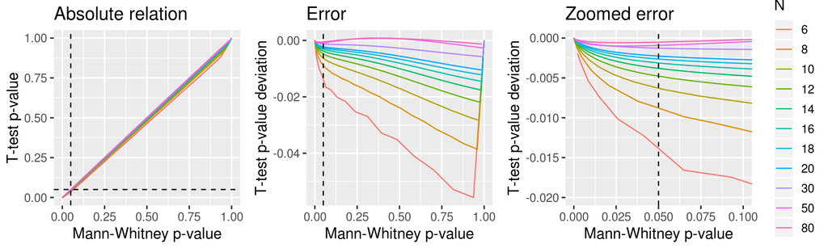

```r
D$N = factor(D$N)  # Make N a factor for prettier plotting

library(ggplot2)
library(patchwork)

# A straight-up comparison of the p-values
p_relative = ggplot(D, aes(x=mann_p.value, y=ttest_p.value, color=N)) +
  geom_line() +
  geom_vline(xintercept=0.05, lty=2) +
  geom_hline(yintercept=0.05, lty=2) +

  labs(title='Absolute relation', x = 'Mann-Whitney p-value', y = 'T-test p-value') +
  #coord_cartesian(xlim=c(0, 0.10), ylim=c(0, 0.11)) +
  theme_gray(13) +
  guides(color=FALSE)

# Looking at the difference (error) between p-values
p_error_all = ggplot(D, aes(x=mann_p.value, y=ttest_p.value-mann_p.value, color=N)) +
  geom_line() +
  geom_vline(xintercept=0.05, lty=2) +

  labs(title='Error', x = 'Mann-Whitney p-value', y = 'T-test p-value deviation') +
  theme_gray(13) +
  guides(color=FALSE)

# Same, but zoomed in around p=0.05
p_error_zoom = ggplot(D, aes(x=mann_p.value, y=ttest_p.value-mann_p.value, color=N)) +
  geom_line() +
  geom_vline(xintercept=0.05, lty=2) +

  labs(title='Zoomed error', x = 'Mann-Whitney p-value', y = 'T-test p-value deviation') +
  coord_cartesian(xlim=c(0, 0.10), ylim=c(-0.020, 0.000)) +
  theme_gray(13)

# Show it. Patchwork is your friend!
p_relative + p_error_all + p_error_zoom
```

# Conclusion